# Chapter 07 Exercises

## Jae Wook Jung

### Jan 22 2020

```python
# Libraries you will need for this assignment.
# The code below will import them for your use.
# Please run this before continuing.
%matplotlib inline
import numpy as np
import pandas as pd
from matplotlib.dates import DateFormatter
import matplotlib.pyplot as plt
import matplotlib.dates as mdates
```

## Q1) The employment-population ratio for men and women (a FRED question)

Using the data below, answer the following questions:

```python
#Run this code to import the data sets
#DO NOT CHANGE THIS CODE
#This is the same code that is in your python homework #__

# URL to first data set:
men_url = "https://raw.githubusercontent.com/dylanjm/econ_381_development/master/data/ch07_employment_ratio_men.csv"

# Import the data and save it to a variable:
men = pd.read_csv(men_url, header = 0, names = ["Date", "Ratio"])

# URL to second data set:
women_url = "https://raw.githubusercontent.com/dylanjm/econ_381_development/master/data/ch07_employment_ratio_women.csv"

# Import the data and save it to a variable:
women = pd.read_csv(women_url, header = 0, names = ["Date", "Ratio"])
```

**(a)**: Create **one** plot with **two** time-series, one for men and one for women. *Hint: in order to get your time series plot to look right, you will need to convert the date variable to a datetime object. I have done this below for the women's data set, and you will need to do it for the men's.* Be sure to include labels, a title, and a legend. You can see another example of this in your chapter 1 homework.

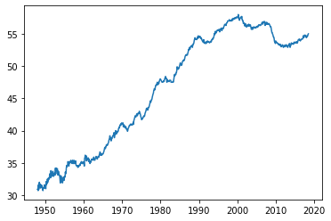

```python
WomenDate = np.array(women['Date'],dtype=np.datetime64)

plt.plot(WomenDate, women["Ratio"])
plt.show()
```

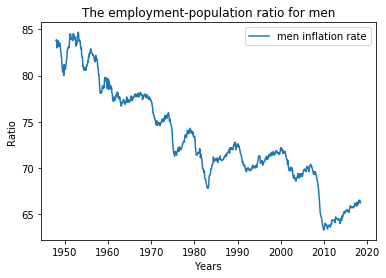

```python
MenDate = np.array(men['Date'], dtype = np.datetime64)
plt.plot(MenDate, men["Ratio"], label = 'men inflation rate')
plt.xlabel('Years')
plt.ylabel('Ratio')
plt.title('The employment-population ratio for men')
plt.legend()
plt.show()
```

**(b)**: What are some possible explanations for the differences between the two series between 1950 and 2000?

Women's employment ratio grew rapidely, and men's employment ratio fell rapidely.But still men's employment is higher than the women's.

**(c)**: What might explain the change in the trend of women's employment since 2000?

Where the women's employment grow, before 2000, the U.S. had civil rights movement. And after 2000 there were some recessons, dotcom-bubble and 2008-9, decreased the employment rate and it's recovering again. There was a limit to hire women in the market. It hitted that point at 2000, and slowly came down.

## Q2) How much is a college education worth?

In the text, we supposed a college education raised a person's wage by \$30,000 per year, from \\$40,000 to \$70,000. Assume the relevant interest rate is 3\%, there is no growth in wages, and you are expected to retire at 65 years old after you graduate high-school.

**(a)**: Suppose you are a 18 year old graduating high school senior deciding whether or not to go to college. What is the present discounted value of your labor earnings if you chose not to attend college? Calculate this by hand and input the answer below.

```python
pdv0 = 40000*((1-(1/1.03)**(47))/(1-(1/1.03)))
print('${:,.2f}'.format(pdv0))
```

```
$1,031,017.96
```

**(b)** What is the present discounted value of your labor earnings if you chose to attend college? Calculate this by hand and input the answer below.

```python
pdv = 70000*((1-(1/1.03)**(43))/(1-(1/1.03)))
print('${:,.2f}'.format(pdv))
```

```
$1,729,095.14
```

**(c)** What is the present discounted value of 4 years of your labor income if you forgo college and start work immediately? Calculate this by hand and input the answer below.

```python
dv = 40000*((1-(1/1.03)**(4))/(1-(1/1.03)))
print('${:,.2f}'.format(dv))
```

```
$153,144.45
```

**(d)**: Suppose that college costs \$20,000 per year. What is the present discounted value of your college education expenses?

```python
pdv = 20000*((1-(1/1.03)**(4))/(1-(1/1.03)))
print('${:,.2f}'.format(pdv))
```

```
$76,572.23
```

**(e)**: What is the net present discounted value of a college education under these assumptions?

```python
pdv1 = (40000*((1-(1/1.03)**(4))/(1-(1/1.03)))) + (20000*((1-(1/(1.03))**(4))/(1-(1/(1.03)))))
print('${:,.2f}'.format(pdv1))
```

```
$229,716.68
```

**(f)** Now, suppose that the relevant interest rate increases to 8\%. How does that change the net present discounted value of your college education? What if instead the cost of attending college doubled? Please discuss your findings.

```python
#increase to 8%
pdv2 = 20000*((1-(1/1.08)**(4))/(1-(1/1.08))) +(40000*((1-(1/1.08)**(4))/(1-(1/1.08))))
print('${:,.2f}'.format(pdv2))
#doubling the tuition
pdv3 = 2*20000*((1-(1/1.03)**(4))/(1-1/(1.03))) + (40000*((1-(1/1.03)**(4))/(1-(1/1.03))))
print('${:,.2f}'.format(pdv3))

print('incresed interest rate makes present discounted value cheaper than lower discounted rate')
print('and doubling the tuition fee makes net present discounted value lot expensive')
```

```
$214,625.82
$306,288.91
incresed interest rate makes present discounted value cheaper than lower discounted rate
and doubling the tuition fee makes net present discounted value lot expensive
```

```python
# 42 yrs high school degree working
pdv5 = 40000*((1-(1/(1.03))**(42))/(1-(1/(1.03))))
print('${:,.2f}'.format(pdv5))
```

```
$976,496.00
```

```python
# 43 yrs college degree working (subtracted net schooling expenses)
pdv6 = (70000*((1-(1/1.03)**(42))/(1-(1/1.03)))) - (40000*((1-(1/1.03)**(4))/(1-(1/1.03))) + 20000*((1-(1/(1.03)**(4)))/1-(1/(1.03))))
pdv7 = (70000*((1-(1/1.03)**(43))/(1-(1/1.03)))) - (40000*((1-(1/1.03)**(4))/(1-(1/1.03))) + 20000*((1-(1/(1.03)**(4)))/1-(1/(1.03))))
pdv8 = pdv7 - pdv6
print('${:,.2f}'.format(pdv6))
print('${:,.2f}'.format(pdv7))
print('${:,.2f}'.format(pdv8))
```

```
$1,572,910.76
$1,593,137.91
$20,227.15
```